# Clustering

2021-10-01

## Introduction

## This tutorial

- In this tutorial, we will investigate the characteristics of clustering.
- We will look at the following concepts
  - distance measures
  - prototypes
  - clustering algorithms
  - cluster evaluation
- We will do so by making use of the R package `dtwclust`.
- We will investigate the methodology on a concrete example: We cluster (simulated) behavioural data from a public good game.
- We will see that the algorithm does a reasonably good job at clustering the data.
- It clusters patterns of observed contributions, combined with patterns of observed experiences.
- However, there is no one-to-one mapping of 5 patterns to 5 types.

## Simulate Type Space

- We simulate decision data from a public goods game with 10 rounds, group size 4, and endowment 20.
- We simulate 5 behavioural types: short-sighted freerider, far-sighted freerider, conditional cooperator, hump-shaped contributor, altruist.
- Each type has a certain reaction function, but it does not act upon it at all times. Therefore, we add noise (\(\sigma\) and \(\eta\)).

🤓: Vary some parameter, e.g. numrounds, sigma, eta, grpsize, endowment.

```r
simdat_grp <- generate_data(numrounds = 10,
                            sigma = .3, eta = 0.3,
                            n = 4,
                            types = c(1,2,3,4,5), grpsize = 4, endowment = 20,
                            rand_first = FALSE, random_subset = FALSE,
                            add_errors = TRUE)
```

```
##    uid group_id contribution grp_cmpstn experience type period      ratio diff
## 5   11        1            0    1 1 1 1          0    1      2 0.04545455  0.5
## 6   12        1            0    1 1 1 1          0    1      2 0.04545455  0.5
## 7   13        1            0    1 1 1 1          0    1      2 0.04545455  0.5
## 8   14        1            0    1 1 1 1          0    1      2 0.04545455  0.5
## 9   11        1            0    1 1 1 1          0    1      3 0.04545455  0.5
## 10  12        1            0    1 1 1 1          0    1      3 0.04545455  0.5
```

`dtwclust` needs the data to be in a specific form (list `ls`) to use it as cluster input.

```r
id<-unique(simdat_grp$uid)
ls <- list()
for (j in 1:length(id)) {
  df_sb<-simdat_grp[simdat_grp$uid==id[j], c("contribution", "experience")]
  ls[[j]]<-df_sb
}
ls <- reinterpolate(x = ls, n = max(simdat_grp$period)-1, multivariate = TRUE)
```

## Distance Measures

## What are Distance Measures?

- Distance measures provide quantification for the dissimilarity between two time series.
- It is a task that is repeated very often and loops across all data objects applying a suitable distance function.

### Characteristics of distance measures implemented in dtwclust.

Table by Sardá-Espinosa (2017).

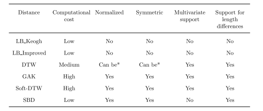

### Dynamic Time Warping

- DTW is a dynamic programming algorithm that compares two series and tries to find the optimum warping path between them.
- DTW is computationally expensive. If \(x\) has length \(n\) and \(y\) has length \(m\), the DTW distance between them can be computed in \(O(nm)\) time, which is quadratic if \(m\) and \(n\) are similar.
- The DTW distance can deal with series of different lengths.

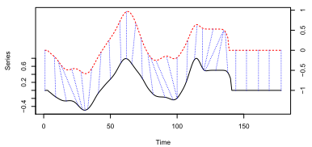

Figure from Sardá-Espinosa (2017)

- The figure shows sample alignment performed by DTW between two series.
- The dashed blue lines exemplify how some points are mapped to each other (warped in time).

### DTW—how does it work?

- Create a local cost matrix \(lcm\), which has \(n\cdot m\) dimensions.
- Such a matrix must be created for every pair of series compared.
- DTW finds the path that minimizes the alignment between \(x\) and \(y\) by iteratively stepping through \(lcm\), starting at \(lcm(1, 1)\) and finishing at \(lcm(n,m)\), and aggregating the cost.
- At each step, the algorithm finds the direction in which the cost increases the least under the chosen constraints.

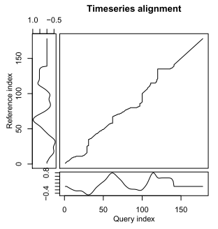

- The figure shows the optimum path found (corresponding to the previous figure).  
- The square in the centre represents the \(lcm\) created for these specific series.

### Soft-DTW

- DTW can be regularized via smoothing (Cuturi 2011).
- Soft-dtw possesses differentiability; Therefore, a gradient function can be obtained.
- The gradient function is used to calculate centroids with numerical optimization.

\[ dtw_\gamma(x, y) = min^\gamma{\langle A,\Delta(x, y)\rangle, A \epsilon A(n,m)} \]

- Disadvantages
  - The distance between \(x\) and itself is not necessarily zero.
  - It has quadratic complexity with respect to the series’ lengths.
- Advantages
  - It supports multivariate series as well as different lengths.
  - It provides smoothed results by a user-defined parameter \(\gamma\).

### Implementation

🤓: Experiment with different parameters (gamma, window size, norm).

```r
distances = pdc_configs(type = "distance",
                        partitional = list(
                          sdtw = list(window.size = window_size,
                          norm = c("L2"),
                          gamma = c(0.001))))
```

- \(\gamma\)
  - If you are interested in the impact of \(\gamma\), read Cuturi (2011), Table 1.
- window
  - global constraint
  - It is common to use a window whose size is 10% of the series’ length.
  - Sometimes smaller windows produce even better results (Ratanamahatana and Keogh 2004).
- norm
  - For each element \((i, j)\) in \(lcm\), the \(l_p\) norm between \(x_i\) and \(y_j\) must be computed.
  - The l1 and l2 vector norms, also known as Manhattan and Euclidean distances.

## Time-series Prototypes

## What are Time-series Prototypes?

- All series within a cluster should be similar to each other.
- One time series should effectively summarize the most important characteristics of all series in a given cluster.
- The distance measure should correspond to the one used by the prototyping function
- A prototype can be generated (e.g. mean) or a reference time-series is chosen.

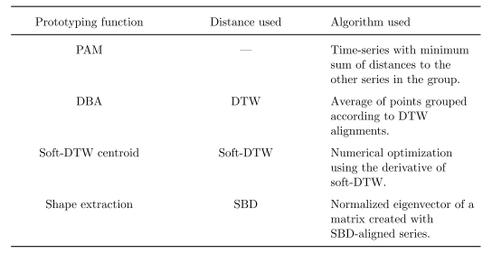

### DTW Barycenter Averaging (DBA)

- DBA requires a series to be used as a centroid.
- It is an iterative, global method: The order in which the series enter the prototyping function does not affect the outcome.
- It can support series with different lengths directly.
- It usually begins by randomly selecting one of the series in the data.
- On each iteration, the DTW alignment between each series in the cluster \(C\) and the centroid is computed.
- This is iteratively repeated until a certain number of iterations are reached, or until convergence is assumed.

```r
centroids = pdc_configs(type = "centroid",
                        partitional = list(
                          dba=list(norm = c('L2'),
                                   znorm = c(FALSE)))) #mean=0, sd=1
```

## Clustering Algorithms

## Three Types of Algorithms

We’ll discuss three different types of algorithms

- Hierarchical clustering (crisp)
- Partitional clustering (crisp)
- Fuzzy clustering

## Hierarchical Clustering

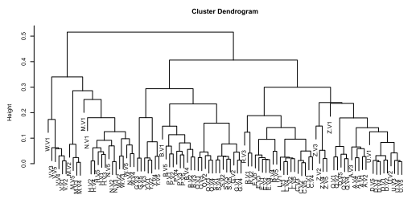

- The procedure is deterministic: It will always give the same result for a chosen set of (dis)similarity measures.
- Algorithms can be agglomerative or divisive (less common).
- In agglomerative procedures, every member of the data starts in its own cluster, and members are grouped together sequentially based on the similarity measure until all members are contained in a single cluster.
- Divisive procedures do the exact opposite.
- Both strategies suffer from a lack of flexibility, because they cannot perform adjustments once a split has been done.

## Partitional Clustering

- The data is explicitly assigned to (only) one cluster out of \(k\) total clusters.
- \(k\) must be specified beforehand.
- It is a combinatorial optimization problem: It minimizes the intra-cluster distance while maximizes the inter-cluster distance.
- Some of the most popular partitional algorithms are k-means and k-medoids.
- Partitional clustering procedures are stochastic due to their random start.
- Thus, it is common practice to test different random starts (via `nrep`) to evaluate several local optima and choose the best result out of all the repetitions.

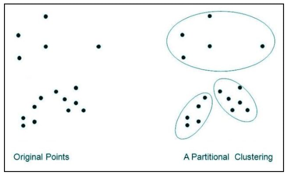

Example for Partitional Clustering, figure from Alhenak and Hosny (2019).

### How does it work?

- First, \(k\) centroids are randomly initialized and assigned to individual clusters.
- The distance between all objects in the data and all centroids is calculated.
- A prototyping function is applied to each cluster to update the corresponding centroid.
- Distances and centroids are updated iteratively until a certain number of iterations (via `iter.max`) have elapsed, or no object changes clusters anymore.

```r
controls = list(partitional = partitional_control(iter.max = 2L,
                                                  nrep = 2L)),
```

## Fuzzy Clustering

- The previous procedures discussed result in what is known as a crisp or hard partition.
- In crisp partitions, each member of the data belongs to only one cluster, and clusters are mutually exclusive.
- Fuzzy Clustering creates a fuzzy or soft partition in which each member belongs to each cluster to a certain degree.
- The degree of belongingness is constrained so that its sum equals \(1\) across all clusters.
- If there are \(N\) objects in the data and \(k\) clusters are desired, an \(N×k\) membership matrix \(u\) can be created, where all the rows must sum to \(1\)

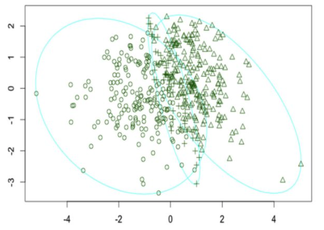

Figure from Bolin et al. (2014)

## Implementation

- Now, let’s combine our knowledge about distance functions, prototypes, and clustering algorithms to define the scoring function `define_config_multi`.

🤓: Use hierarchical (instead of partitional) clustering.

```r
define_config_multi <- function(num_clust, window_size, typs = c("p")){
  cfgs <- compare_clusterings_configs(
    types = typs,
    k = num_clust,
    controls = list(partitional = partitional_control(iter.max = 2L, nrep = 2L)),
    preprocs = pdc_configs(type = "preproc",
                           none = list(),
                           share.config = c("p")),
    distances = pdc_configs(type = "distance",
                            partitional = list(
                              sdtw = list(window.size = window_size, norm = c("L2"),
                                          gamma = c(0.001)))),
    centroids = pdc_configs(type = "centroid",
                            partitional = list(
                              dba=list(norm = c('L2'), znorm = c(FALSE)))))
  return(cfgs)
}

cfgs<-define_config_multi(num_clust = c(10:20), window_size = 1)
```

## Cluster Evaluation

## Cluster Validity Indices

- Clustering is an unsupervised procedure.
- Evaluating its performance can be subjective.
- To standardize cluster evaluation, various cluster validity indices (CVIs) have been developed.
- A comprehensive overview can be found in Arbelaitz et al. (2013).
- CVIs can be either tailored to crisp or fuzzy partitions.
  - Crisp: CVIs can be classified as internal or external
    - Internal CVIs only consider the partitioned data and try to define a measure of cluster purity.
    - External CVIs compare the obtained partition to the correct one. Thus, external CVIs can only be used if the ground truth is known.

```r
internal_evaluators<-cvi_evaluators("internal", fuzzy = FALSE)
score_internal <- internal_evaluators$score
```

## Cluster Validity Indices

- Most of the CVIs estimate the cluster cohesion (within or intra-variance) and the cluster separation (between or inter-variance) and combine them to compute a quality measure.
- The combination is performed by a division (ratio-type indices) or a sum (summation-type indices) (Kim and Ramakrishna 2005).

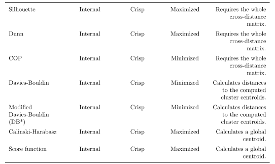

- Knowing which CVI will work best cannot be determined a priori, so they should be tested for each specific application.
- Many CVIs can be utilized and compared to each other, e.g. by using a majority vote to decide on a final result.

```r
pick_majority <- internal_evaluators$pick
```

## Implementation

This is where the actual clustering takes place.

```r
require(doParallel)
registerDoParallel(cl <- makeCluster(detectCores()))

comparison <- compare_clusterings( ls,
                                   types = c("p"),
                                   configs = cfgs,
                                   score.clus = score_internal,
                                   pick.clus = pick_majority,
                                   trace = TRUE,
                                   return.objects = TRUE)
```

```
## =================================== Preprocessing series ===================================
```

```
## -------------- Applying partitional preprocessings: --------------
```

```
##   preproc
## 1    none
```

```
## =================================== Performing partitional clusterings ===================================
```

Next, we transform the `comparison` object which is the result of the clustering to `df_clust`.

```r
clust_data<-comparison[["pick"]][["object"]]@datalist
names(clust_data)<-id
clust_data <- lapply(seq_along(clust_data), ## make one DF out of list of matrices
                     function(i) {
                       data.frame(uid = i,
                                  study=names(clust_data)[i],
                                  contribution=clust_data[[i]][,"contribution"],
                                  experience=clust_data[[i]][,"experience"],
                                  period=2:(dim(clust_data[[i]])[1]+1))
                     })
clust_data<-do.call(rbind, clust_data)

clust_clust<-as.data.frame(comparison[["pick"]][["object"]]@cluster)
clust_clust$uid<-1:dim(clust_clust)[1]

df_clust<-merge(clust_data, clust_clust, by = "uid")  # cluster from the simulated df
colnames(df_clust)[6]<-"cluster"
```

Next, we reshape `df_clust` from wide to long to be able to plot it via ggplot.

```r
df_clust_lng <- gather(df_clust, who, contribution, contribution:experience, factor_key=TRUE)
df_clust_lng$clust<-factor(df_clust_lng$clust)
df_clust_lng$study<-factor(df_clust_lng$study)
colnames(df_clust_lng)[6]<-"contribution"
head(df_clust_lng)
```

```
##   uid study period cluster          who contribution clust
## 1   1    11      2      20 contribution         0.00    20
## 2   1    11      3      20 contribution         0.00    20
## 3   1    11      4      20 contribution         0.00    20
## 4   1    11      5      20 contribution         0.00    20
## 5   1    11      6      20 contribution         0.05    20
## 6   1    11      7      20 contribution         0.00    20
```

## Plot CVIs

- Next, we want to plot the internal CVIs.
- Please note that the following chunks only makes sense if you passed \(k>1\) to the clustering function.
- First, we extract the CVIs and standardize them \(\epsilon [0,1]\) to make them comparable.

🤓: You do not have to use all CVIs available. Experiment with a subset.

```r
expintCVI<-comparison[["results"]][["partitional"]]
cvis<-c("Sil","D","COP","DB","DBstar","CH","SF")
expintCVI[cvis] <- lapply(expintCVI[,cvis],
                           function(x){(x-min(x))/(max(x)-min(x))})
```

- We go on and recode those CVIs that need to be minimized (instead of maximized).

```r
expintCVI$COP <- 1 - expintCVI$COP
expintCVI$DBstar <- 1 - expintCVI$DBstar
expintCVI$DB <- 1 - expintCVI$DB

expintCVI<-expintCVI[expintCVI$gamma_distance==0.001,]
```

- We use partitional clustering with several restarts.
- Therefore, we either need to average the results or pick one round.

```r
CVI_long <- gather(expintCVI[expintCVI$rep==1, c("k",cvis)], CVIs, CVI_val, Sil:SF, factor_key=TRUE)
```

## Calculate Rankvote

- The majority vote of all CVIs is often inconclusive.
- We therefore proceed the following way: for each choice parameter in question, we rank the scores of each CVI.
- For each outcome, we calculate the sum over all 7 ranks.
- We choose the parameter that receives the highest sum of ranks.

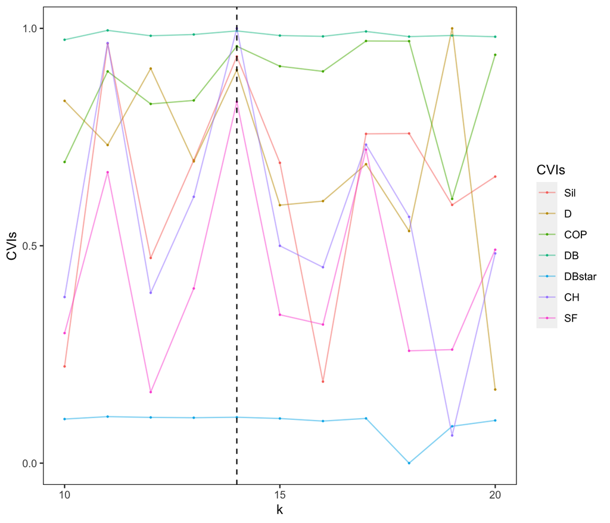

## Plot cluster versus types

Here we add the cluster information from the `comparison` object to the dataframe including the simulated data.

```r
simdat_grp<-simdat_grp[,1:9]
simdat_grp$type[simdat_grp$type == '1'] <- 'short-sighted freerider'
simdat_grp$type[simdat_grp$type == '2'] <- 'hump shaped'
simdat_grp$type[simdat_grp$type == '3'] <- 'conditional cooperator'
simdat_grp$type[simdat_grp$type == '4'] <- 'altruist'
simdat_grp$type[simdat_grp$type == '5'] <- 'far-sighted freerider'

simclust <- as.data.frame(comparison[["pick"]][["object"]]@cluster)
simclust <- cbind(simclust, id)
names(simclust) <- c("clust", "uid")
simdat_grp <- merge(simdat_grp, simclust, by = "uid")  ##add cluster information
```

Again, we reshape the data frame from wide to long to plot it via ggplot.

```r
data_long <- gather(simdat_grp[, c("uid", "period", "contribution", "experience", "clust", "type")],
                    who, contribution, contribution:experience, factor_key=TRUE)
head(data_long)
```

```
##   uid period clust                    type          who contribution
## 1  11      2    20 short-sighted freerider contribution         0.00
## 2  11      9    20 short-sighted freerider contribution         0.05
## 3  11      6    20 short-sighted freerider contribution         0.05
## 4  11      3    20 short-sighted freerider contribution         0.00
## 5  11     10    20 short-sighted freerider contribution         0.00
## 6  11      7    20 short-sighted freerider contribution         0.00
```

## Cluster Found

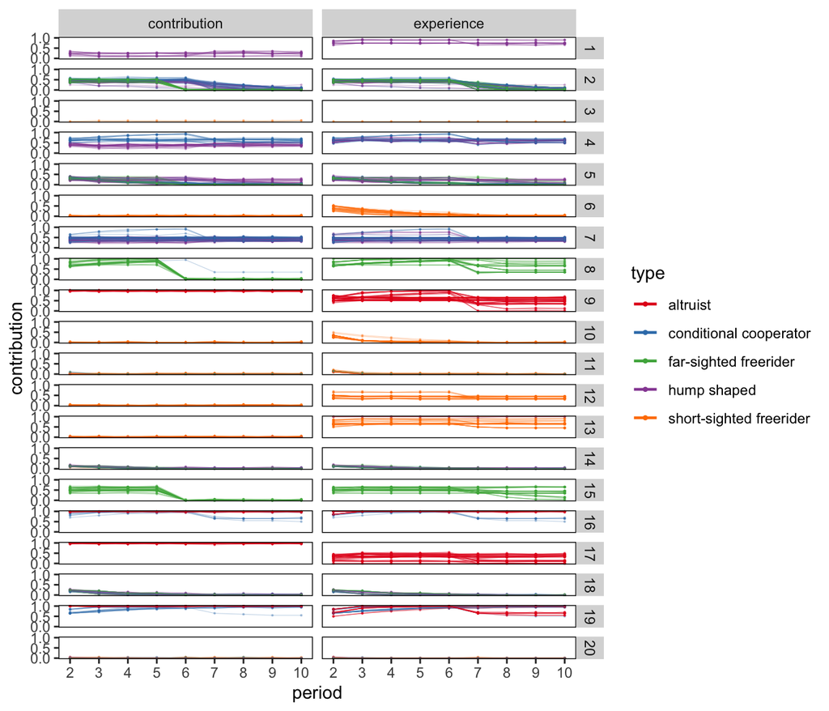

## Types Simulated

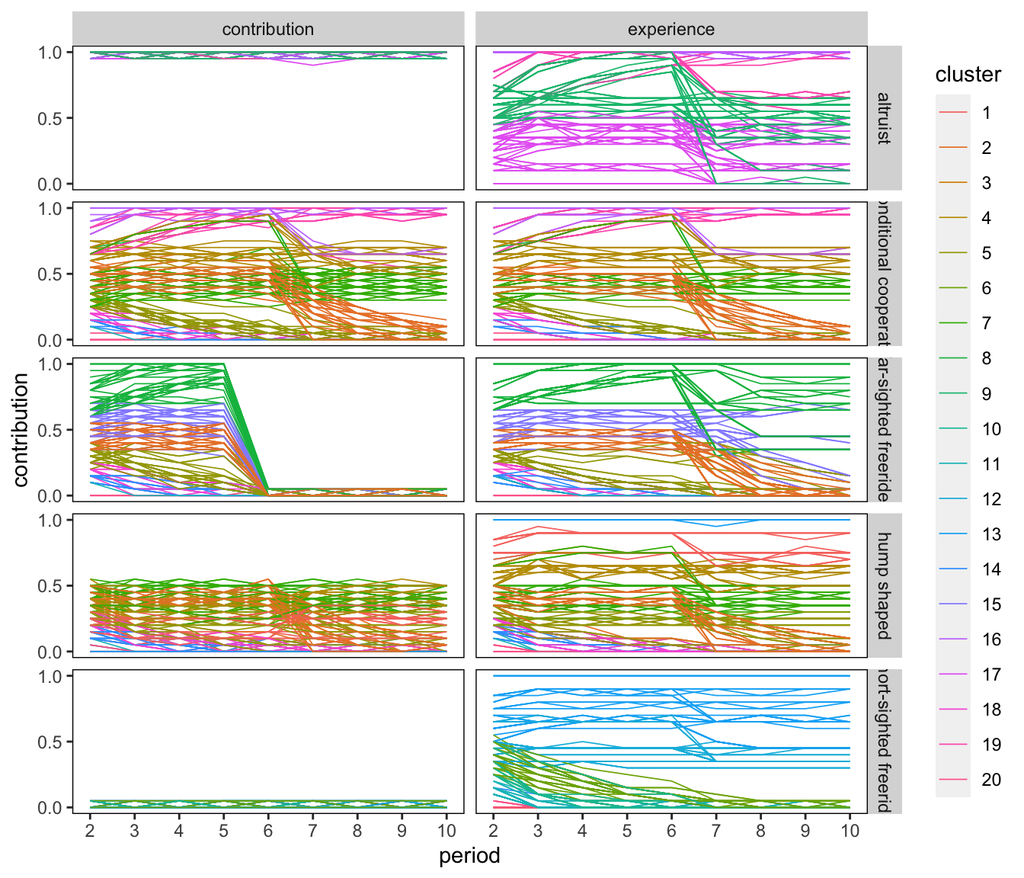

## It’s your turn! 👩‍💻 ~15’

## References

Alhenak, Lubna, and Manar Hosny. 2019. “ Genetic-frog-leaping algorithm for text document clustering.” King Saud University.

Arbelaitz, Olatz, Ibai Gurrutxaga, Javier Muguerza, JesúS M PéRez, and IñIgo Perona. 2013. “ An extensive comparative study of cluster validity indices.” *Pattern Recognition* 46 (1): 243–56. https://www.sciencedirect.com/science/article/abs/pii/S003132031200338X.

Bolin, Jocelyn H, Julianne M Edwards, W Holmes Finch, and Jerrell C Cassady. 2014. “ Applications of cluster analysis to the creation of perfectionism profiles: a comparison of two clustering approaches.” *Frontiers in Psychology* 5: 343.

Cuturi, Marco. 2011. “ Fast Global Alignment Kernels.” In *Proceedings of the 28th International Conference on Machine Learning, ICML 2011*, 929–36.

Kim, Minho, and R S Ramakrishna. 2005. “ New indices for cluster validity assessment.” *Pattern Recognition Letters* 26 (15): 2353–63.

Ratanamahatana, Chotirat Ann, and Eamonn Keogh. 2004. “ Making time-series classification more accurate using learned constraints.” In *Proceedings of the 2004 SIAM International Conference on Data Mining*, 11–22. SIAM.

Sardá-Espinosa, Alexis. 2017. “ Comparing time-series clustering algorithms in r using the dtwclust package.” *R Package Vignette* 12: 41.